# Kevin_Pollard_HW3

Kevin Pollard

4/22/2020

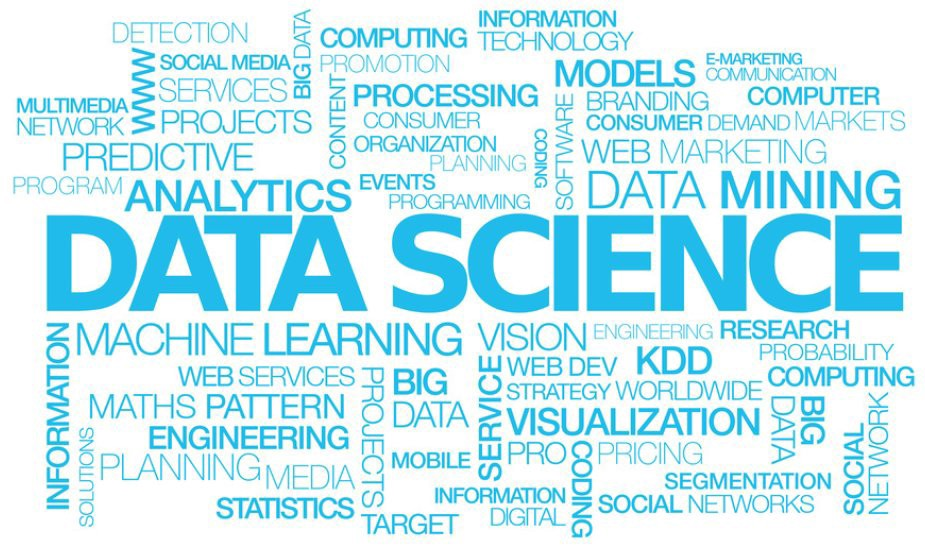

# Introduction

The marketing department of KNJ Financial keeps records on customers, including demographic information and, number of type of accounts. When launching a new product, such as a “Personal Equity Plan” (PEP), a direct mail piece, advertising the product, is sent to existing customers, and a record kept as to whether that customer responded and bought the product. Based on this store of prior experience, the managers decide to use data mining techniques to build customer profile models.

The personal equity plan was designed to encourage investment by individuals. Many plans required a minimum amount to be invested, depending on the type of plan and the plan manager’s requirements. The individuals who responded to the PEP direct mailer piece indicate a wiliness to both save money and respond marketing mailers from KNJ Financial. It is a fair assumption these same customer will likely repond to future campaigns, but more analysis is required.

The type of analysis recommended for the managers to leverage is called **propensity to buy.** The purpose of a propensity to buy analysis is to understand the likelihood a customer will be predisposed to purchasing a product based upon purchases they’ve already made. A few data mining techniques will be introduced in the sections below, and concepts will be explained along the way.

# Analysis and Models

## About the Data

### Data Loading

KNJ finance has provided the bankdata_csv_all.csv file to support the analysis.

### Data Structure

The data has 600 observations with 12 features to describe each. The id field has no value and will be elinated from the analysis.

The data contains of a number of the following fields:

- id a unique identification number
- age age of customer in years
- sex MALE / FEMALE
- region inner_city/rural/suburban/town
- income income of customer
- married Is the customer married (YES/NO)
- children number of children
- car Does the customer own a car (YES/NO)
- save_acct Does the customer have a saving account (YES/NO)
- current_acct Does the customer have a current account (YES/NO)
- mortgage Does the customer have a mortgage (YES/NO)
- pep Did the customer buy a PEP after the last mailing (YES/NO

```
## 'data.frame':    600 obs. of  12 variables:
##  $ id         : Factor w/ 600 levels "ID12101","ID12102",..: 1 2 3 4 5 6 7 8 9 10 ...
##  $ age        : int  48 40 51 23 57 57 22 58 37 54 ...
##  $ sex        : Factor w/ 2 levels "FEMALE","MALE": 1 2 1 1 1 1 2 2 1 2 ...
##  $ region     : Factor w/ 4 levels "INNER_CITY","RURAL",..: 1 4 1 4 2 4 2 4 3 4 ...
##  $ income     : num  17546 30085 16575 20375 50576 ...
##  $ married    : Factor w/ 2 levels "NO","YES": 1 2 2 2 2 2 1 2 2 2 ...
##  $ children   : int  1 3 0 3 0 2 0 0 2 2 ...
##  $ car        : Factor w/ 2 levels "NO","YES": 1 2 2 1 1 1 1 2 2 2 ...
##  $ save_act   : Factor w/ 2 levels "NO","YES": 1 1 2 1 2 2 1 2 1 2 ...
##  $ current_act: Factor w/ 2 levels "NO","YES": 1 2 2 2 1 2 2 2 1 2 ...
##  $ mortgage   : Factor w/ 2 levels "NO","YES": 1 2 1 1 1 1 1 1 1 1 ...
##  $ pep        : Factor w/ 2 levels "NO","YES": 2 1 1 1 1 2 2 1 1 1 ...
```

### Data Tidiness and Completeness

The banking data is clean with no NA, incomplete sets, or duplicate records.

```
##                                             a
## 1 Complete Cases?  TRUE  Incomplete Count:  0
```

| columns | percent_missing |
| --- | --- |
| id | 0 |
| age | 0 |
| sex | 0 |
| region | 0 |
| income | 0 |
| married | 0 |
| children | 0 |
| car | 0 |
| save_act | 0 |
| current_act | 0 |
| mortgage | 0 |
| pep | 0 |

| columns | count_missing |
| --- | --- |
| id | 0 |
| age | 0 |
| sex | 0 |
| region | 0 |
| income | 0 |
| married | 0 |
| children | 0 |
| car | 0 |
| save_act | 0 |
| current_act | 0 |
| mortgage | 0 |
| pep | 0 |

| d |
| --- |
| Duplicate Count: 0 |

```
## [1] "summary"
```

```
##   pep          income           age        married
##  NO :326   Min.   : 5014   Min.   :18.00   NO :204
##  YES:274   1st Qu.:17265   1st Qu.:30.00   YES:396
##            Median :24925   Median :42.00
##            Mean   :27524   Mean   :42.40
##            3rd Qu.:36173   3rd Qu.:55.25
##            Max.   :63130   Max.   :67.00
```

```
## [1] "summary"
```

```
##     children     current_act save_act   car
##  Min.   :0.000   NO :145     NO :186   NO :304
##  1st Qu.:0.000   YES:455     YES:414   YES:296
##  Median :1.000
##  Mean   :1.012
##  3rd Qu.:2.000
##  Max.   :3.000
```

Proportions of the feature data are found below here. The Pep proportions of YES = 0.46 means a very large portion of KNJ customers responded to the pep mailer. This bodes well, since past responders or purchasers of services tend to respond again.

Checking proportions of the original data.

- “Pep proportions NO= 0.54 YES= 0.46”
- “Car proportions NO= 0.51 YES= 0.49”
- “Married proportions NO= 0.34 YES= 0.66”
- “Children proportions 0= 0.44 1= 0.22 2= 0.22 3= 0.11”
- “Mortgage proportions NO= 0.65 YES= 0.35”
- “Savings Account proportions NO= 0.31 YES= 0.69”

The table below shows top 10 customers arranged by income **income high to low.**.

- Most of the top 10 by income have responded to the Personal Equity Plan" mailer.
- All have savings and current accounts.
- The majority are married females who are retirement age.
- This cross section doesn’t have a lotof mortgages, so maybe the mortagees are paid off and kids left the nest.

These points should help inform a deeper analysis.

| id | age | sex | region | income | married | children | car | save_act | current_act | mortgage | pep |
| --- | --- | --- | --- | --- | --- | --- | --- | --- | --- | --- | --- |
| ID12291 | 67 | FEMALE | SUBURBAN | 63130.1 | YES | 2 | YES | YES | YES | NO | YES |
| ID12558 | 65 | FEMALE | INNER_CITY | 61554.6 | YES | 0 | NO | YES | YES | NO | NO |
| ID12371 | 67 | FEMALE | SUBURBAN | 60747.5 | NO | 2 | NO | YES | YES | YES | YES |
| ID12605 | 63 | FEMALE | INNER_CITY | 59805.6 | YES | 1 | YES | YES | YES | NO | YES |
| ID12111 | 66 | FEMALE | TOWN | 59803.9 | YES | 0 | NO | YES | YES | NO | NO |
| ID12235 | 66 | FEMALE | TOWN | 59503.8 | YES | 2 | YES | YES | YES | YES | YES |
| ID12307 | 63 | MALE | INNER_CITY | 59409.1 | NO | 0 | YES | YES | YES | NO | YES |
| ID12631 | 64 | MALE | SUBURBAN | 59175.1 | YES | 1 | NO | YES | YES | NO | YES |
| ID12532 | 64 | FEMALE | TOWN | 58367.3 | YES | 1 | YES | YES | YES | NO | YES |
| ID12513 | 67 | FEMALE | INNER_CITY | 58092.0 | NO | 2 | YES | YES | YES | NO | YES |

The table below shows top 10 customers arranged by **income low to high.**

- Most did not respond to the pep mailer
- The majority are not married

These points may also be significant.

| id | age | sex | region | income | married | children | car | save_act | current_act | mortgage | pep |
| --- | --- | --- | --- | --- | --- | --- | --- | --- | --- | --- | --- |
| ID12165 | 21 | MALE | TOWN | 5014.21 | NO | 0 | YES | YES | YES | YES | NO |
| ID12679 | 18 | MALE | INNER_CITY | 6294.21 | NO | 0 | NO | YES | YES | YES | NO |
| ID12512 | 22 | MALE | INNER_CITY | 7304.20 | NO | 0 | YES | YES | YES | YES | NO |
| ID12264 | 21 | FEMALE | TOWN | 7549.38 | NO | 1 | YES | NO | YES | NO | NO |
| ID12347 | 23 | FEMALE | INNER_CITY | 7606.25 | NO | 3 | YES | NO | NO | NO | NO |
| ID12656 | 20 | FEMALE | TOWN | 7723.93 | YES | 2 | YES | YES | YES | NO | NO |
| ID12473 | 24 | FEMALE | INNER_CITY | 7756.36 | NO | 0 | NO | NO | NO | NO | YES |
| ID12197 | 22 | MALE | INNER_CITY | 7948.62 | YES | 1 | NO | NO | NO | YES | NO |
| ID12651 | 23 | FEMALE | INNER_CITY | 8020.19 | YES | 1 | YES | NO | YES | NO | NO |
| ID12172 | 21 | MALE | INNER_CITY | 8062.73 | NO | 0 | NO | NO | YES | NO | YES |

### Summary Stats Analysis

- The average age of the customer population is 42, and 44% of them have no children.
- Average income is $27,524.

```
## [1] 600  12
```

```
## [1] "---------------------------------------------------------------"
## [1] "age"
## [1] "---------------------------------------------------------------"
## [1] "mean:  42.395"
## [1] "median:  42"
## [1] "min:  18"
## [1] "max:  67"
## [1] "range:  49"
## [1] "sd:  14.424947377538"
## [1] "quantile:  18"    "quantile:  30"    "quantile:  42"    "quantile:  55.25"
## [5] "quantile:  67"
## [1] "IQR:  25.25"
## [1] "---------------------------------------------------------------"
## [1] "income"
## [1] "---------------------------------------------------------------"
```

[output cut: 20 more lines]

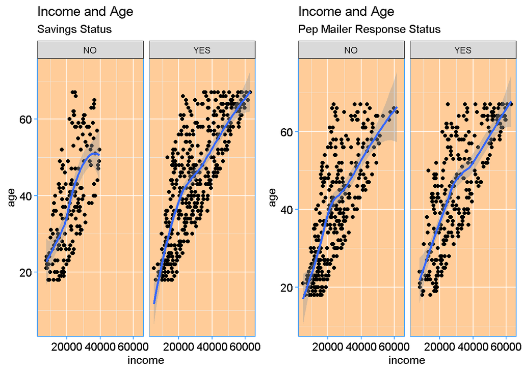

[figure not shown]

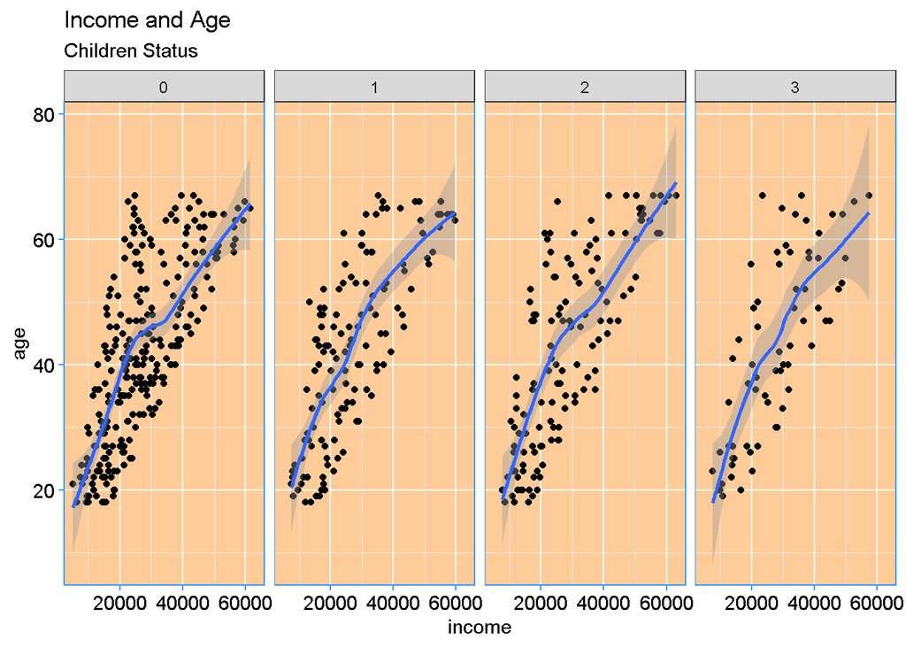

[figure not shown]

## Data Transforms

Discretization and numeric-to-nominal transformation is necessary for the Apriori algorithm to be used. The following transformations will be applied to the data.

- Discretize age by customized bin
- Discretize income by equal-width bin
- Convert numeric to nominal for “children”
- Now the second step of conversion, changing “YES” to “[variable_name]=YES”.

```
## 'data.frame':    600 obs. of  11 variables:
##  $ age        : int  48 40 51 23 57 57 22 58 37 54 ...
##  $ sex        : Factor w/ 2 levels "FEMALE","MALE": 1 2 1 1 1 1 2 2 1 2 ...
##  $ region     : Factor w/ 4 levels "INNER_CITY","RURAL",..: 1 4 1 4 2 4 2 4 3 4 ...
##  $ income     : num  17546 30085 16575 20375 50576 ...
##  $ married    : Factor w/ 2 levels "NO","YES": 1 2 2 2 2 2 1 2 2 2 ...
##  $ children   : int  1 3 0 3 0 2 0 0 2 2 ...
##  $ car        : Factor w/ 2 levels "NO","YES": 1 2 2 1 1 1 1 2 2 2 ...
##  $ save_act   : Factor w/ 2 levels "NO","YES": 1 1 2 1 2 2 1 2 1 2 ...
##  $ current_act: Factor w/ 2 levels "NO","YES": 1 2 2 2 1 2 2 2 1 2 ...
##  $ mortgage   : Factor w/ 2 levels "NO","YES": 1 2 1 1 1 1 1 1 1 1 ...
##  $ pep        : Factor w/ 2 levels "NO","YES": 2 1 1 1 1 2 2 1 1 1 ...
```

| age | sex | region | income | married | children | car | save_act | current_act | mortgage | pep |
| --- | --- | --- | --- | --- | --- | --- | --- | --- | --- | --- |
| fourties | FEMALE | INNER_CITY | 17546.0 | NO | 1 | NO | NO | NO | NO | YES |
| thirties | MALE | TOWN | 30085.1 | YES | 3 | YES | NO | YES | YES | NO |
| fifties | FEMALE | INNER_CITY | 16575.4 | YES | 0 | YES | YES | YES | NO | NO |
| twenties | FEMALE | TOWN | 20375.4 | YES | 3 | NO | NO | YES | NO | NO |
| fifties | FEMALE | RURAL | 50576.3 | YES | 0 | NO | YES | NO | NO | NO |
| fifties | FEMALE | TOWN | 37869.6 | YES | 2 | NO | YES | YES | NO | YES |

| age | sex | region | income | married | children | car | save_act | current_act | mortgage | pep |
| --- | --- | --- | --- | --- | --- | --- | --- | --- | --- | --- |
| fourties | FEMALE | INNER_CITY | (5.01e+03,2.44e+04] | NO | 1 | NO | NO | NO | NO | YES |
| thirties | MALE | TOWN | (2.44e+04,4.38e+04] | YES | 3 | YES | NO | YES | YES | NO |
| fifties | FEMALE | INNER_CITY | (5.01e+03,2.44e+04] | YES | 0 | YES | YES | YES | NO | NO |
| twenties | FEMALE | TOWN | (5.01e+03,2.44e+04] | YES | 3 | NO | NO | YES | NO | NO |
| fifties | FEMALE | RURAL | (4.38e+04,6.31e+04] | YES | 0 | NO | YES | NO | NO | NO |
| fifties | FEMALE | TOWN | (2.44e+04,4.38e+04] | YES | 2 | NO | YES | YES | NO | YES |

| age | sex | region | income | married | children | car | save_act | current_act | mortgage | pep |
| --- | --- | --- | --- | --- | --- | --- | --- | --- | --- | --- |
| fourties | FEMALE | INNER_CITY | (5.01e+03,2.44e+04] | NO | 1 | NO | NO | NO | NO | YES |
| thirties | MALE | TOWN | (2.44e+04,4.38e+04] | YES | 3 | YES | NO | YES | YES | NO |
| fifties | FEMALE | INNER_CITY | (5.01e+03,2.44e+04] | YES | 0 | YES | YES | YES | NO | NO |
| twenties | FEMALE | TOWN | (5.01e+03,2.44e+04] | YES | 3 | NO | NO | YES | NO | NO |
| fifties | FEMALE | RURAL | (4.38e+04,6.31e+04] | YES | 0 | NO | YES | NO | NO | NO |
| fifties | FEMALE | TOWN | (2.44e+04,4.38e+04] | YES | 2 | NO | YES | YES | NO | YES |

| age | sex | region | income | married | children | car | save_act | current_act | mortgage | pep |
| --- | --- | --- | --- | --- | --- | --- | --- | --- | --- | --- |
| fourties | FEMALE | INNER_CITY | (5.01e+03,2.44e+04] | married=NO | 1 | car=NO | save_act=NO | current_act=NO | mortgage=NO | pep=YES |
| thirties | MALE | TOWN | (2.44e+04,4.38e+04] | married=YES | 3 | car=YES | save_act=NO | current_act=YES | mortgage=YES | pep=NO |
| fifties | FEMALE | INNER_CITY | (5.01e+03,2.44e+04] | married=YES | 0 | car=YES | save_act=YES | current_act=YES | mortgage=NO | pep=NO |
| twenties | FEMALE | TOWN | (5.01e+03,2.44e+04] | married=YES | 3 | car=NO | save_act=NO | current_act=YES | mortgage=NO | pep=NO |
| fifties | FEMALE | RURAL | (4.38e+04,6.31e+04] | married=YES | 0 | car=NO | save_act=YES | current_act=NO | mortgage=NO | pep=NO |
| fifties | FEMALE | TOWN | (2.44e+04,4.38e+04] | married=YES | 2 | car=NO | save_act=YES | current_act=YES | mortgage=NO | pep=YES |

## Application of the Apriori algothim

The **Apriori algorithm** can now be used on the transofrmed data to generate association rules. Parameters of support,confidence and lift will be leveraged to study rules that will inform KNJ’s targeted marking campaigns.

- **Support**: This measure gives an idea of how frequent an itemset is in all the transactions.
- **Confidence**: Confidence is an indication of how often the rule has been found to be true.
- **Lift**: Lift is the ratio of the observed support to that expected

Several different combinations of the support, and confidence were use to filter the universe of strong rules for the KNJ Financial data. * Set support: .11 * Set confidence: .79 * Set lift: >= 1

A set of 29 strong rules was obtained from these parameters about. Those 29 are filtered more to get the top 5 strong rules.

```
## Apriori
##
## Parameter specification:
##  confidence minval smax arem  aval originalSupport maxtime support minlen
##        0.75    0.1    1 none FALSE            TRUE       5    0.07      1
##  maxlen target   ext
##       3  rules FALSE
##
## Algorithmic control:
##  filter tree heap memopt load sort verbose
##     0.1 TRUE TRUE  FALSE TRUE    2    TRUE
##
## Absolute minimum support count: 42
##
## set item appearances ...[0 item(s)] done [0.00s].
## set transactions ...[31 item(s), 600 transaction(s)] done [0.00s].
## sorting and recoding items ... [30 item(s)] done [0.00s].
## creating transaction tree ... done [0.00s].
## checking subsets of size 1 2 3 done [0.00s].
## writing ... [194 rule(s)] done [0.00s].
## creating S4 object  ... done [0.00s].
```

|  | LHS | RHS | support | confidence | lift | count |
| --- | --- | --- | --- | --- | --- | --- |
| [1] | {} | {current_act=current_act=YES} | 0.758333333333333 | 0.758333333333333 | 1 | 455 |
| [2] | {region=SUBURBAN} | {current_act=current_act=YES} | 0.0833333333333333 | 0.806451612903226 | 1.0634526763559 | 50 |
| [3] | {children=3} | {pep=pep=NO} | 0.0916666666666667 | 0.808823529411765 | 1.48863226272104 | 55 |
| [4] | {children=3} | {current_act=current_act=YES} | 0.085 | 0.75 | 0.989010989010989 | 51 |
| [5] | {income=(4.38e+04,6.31e+04]} | {save_act=save_act=YES} | 0.133333333333333 | 1 | 1.44927536231884 | 80 |
| [6] | {income=(4.38e+04,6.31e+04]} | {current_act=current_act=YES} | 0.105 | 0.7875 | 1.03846153846154 | 63 |
| [7] | {age=old} | {save_act=save_act=YES} | 0.128333333333333 | 0.855555555555556 | 1.23993558776167 | 77 |
| [8] | {region=RURAL} | {current_act=current_act=YES} | 0.12 | 0.75 | 0.989010989010989 | 72 |
| [9] | {age=fifties} | {current_act=current_act=YES} | 0.13 | 0.772277227722772 | 1.01838755304102 | 78 |
| [10] | {age=twenties} | {income=(5.01e+03,2.44e+04]} | 0.186666666666667 | 0.941176470588235 | 1.9884009942005 | 112 |

[output cut: 184 more lines]

|  | LHS | RHS | support | confidence | lift | count |
| --- | --- | --- | --- | --- | --- | --- |
| [1] | {income=(4.38e+04,6.31e+04]} | {save_act=save_act=YES} | 0.133333333333333 | 1 | 1.44927536231884 | 80 |
| [2] | {age=old} | {save_act=save_act=YES} | 0.128333333333333 | 0.855555555555556 | 1.23993558776167 | 77 |
| [3] | {age=twenties} | {income=(5.01e+03,2.44e+04]} | 0.186666666666667 | 0.941176470588235 | 1.9884009942005 | 112 |
| [4] | {children=1} | {pep=pep=YES} | 0.183333333333333 | 0.814814814814815 | 1.78426601784266 | 110 |
| [5] | {married=married=NO} | {current_act=current_act=YES} | 0.27 | 0.794117647058823 | 1.04718810601164 | 162 |
| [6] | {age=twenties,pep=pep=NO} | {income=(5.01e+03,2.44e+04]} | 0.121666666666667 | 0.924050632911392 | 1.9522196469959 | 73 |
| [7] | {age=twenties,mortgage=mortgage=NO} | {income=(5.01e+03,2.44e+04]} | 0.126666666666667 | 0.938271604938272 | 1.98226395409494 | 76 |
| [8] | {age=twenties,married=married=YES} | {income=(5.01e+03,2.44e+04]} | 0.121666666666667 | 0.948051948051948 | 2.00292665081397 | 73 |
| [9] | {age=twenties,save_act=save_act=YES} | {income=(5.01e+03,2.44e+04]} | 0.113333333333333 | 0.931506849315068 | 1.96797221686282 | 68 |
| [10] | {age=twenties,current_act=current_act=YES} | {income=(5.01e+03,2.44e+04]} | 0.145 | 0.945652173913043 | 1.99785670545009 | 87 |

[output cut: 19 more lines]

|  | LHS | RHS | support | confidence | lift | count |
| --- | --- | --- | --- | --- | --- | --- |
| [1] | {income=(4.38e+04,6.31e+04]} | {save_act=save_act=YES} | 0.133333333333333 | 1 | 1.44927536231884 | 80 |
| [2] | {age=old} | {save_act=save_act=YES} | 0.128333333333333 | 0.855555555555556 | 1.23993558776167 | 77 |
| [3] | {age=twenties} | {income=(5.01e+03,2.44e+04]} | 0.186666666666667 | 0.941176470588235 | 1.9884009942005 | 112 |
| [4] | {children=1} | {pep=pep=YES} | 0.183333333333333 | 0.814814814814815 | 1.78426601784266 | 110 |
| [5] | {married=married=NO} | {current_act=current_act=YES} | 0.27 | 0.794117647058823 | 1.04718810601164 | 162 |
| [6] | {age=twenties,pep=pep=NO} | {income=(5.01e+03,2.44e+04]} | 0.121666666666667 | 0.924050632911392 | 1.9522196469959 | 73 |
| [7] | {age=twenties,mortgage=mortgage=NO} | {income=(5.01e+03,2.44e+04]} | 0.126666666666667 | 0.938271604938272 | 1.98226395409494 | 76 |
| [8] | {age=twenties,married=married=YES} | {income=(5.01e+03,2.44e+04]} | 0.121666666666667 | 0.948051948051948 | 2.00292665081397 | 73 |
| [9] | {age=twenties,save_act=save_act=YES} | {income=(5.01e+03,2.44e+04]} | 0.113333333333333 | 0.931506849315068 | 1.96797221686282 | 68 |
| [10] | {age=twenties,current_act=current_act=YES} | {income=(5.01e+03,2.44e+04]} | 0.145 | 0.945652173913043 | 1.99785670545009 | 87 |

[output cut: 19 more lines]

### Plot 29 Strong Rules

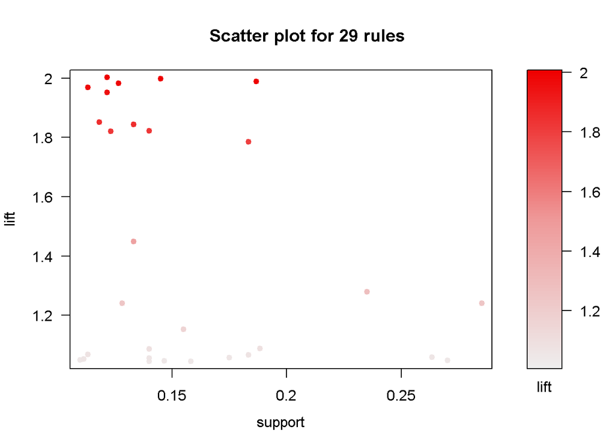

```
## Itemsets in Antecedent (LHS)
##  [1] "{age=twenties,married=married=YES}"
##  [2] "{age=twenties,current_act=current_act=YES}"
##  [3] "{age=twenties}"
##  [4] "{age=twenties,mortgage=mortgage=NO}"
##  [5] "{age=twenties,save_act=save_act=YES}"
##  [6] "{age=twenties,pep=pep=NO}"
##  [7] "{children=1,save_act=save_act=YES}"
##  [8] "{children=1,current_act=current_act=YES}"
##  [9] "{married=married=YES,children=1}"
## [10] "{children=1}"
## [11] "{children=1,mortgage=mortgage=NO}"
## [12] "{income=(4.38e+04,6.31e+04]}"
## [13] "{children=0,pep=pep=NO}"
## [14] "{age=old}"
```

[output cut: 18 more lines]

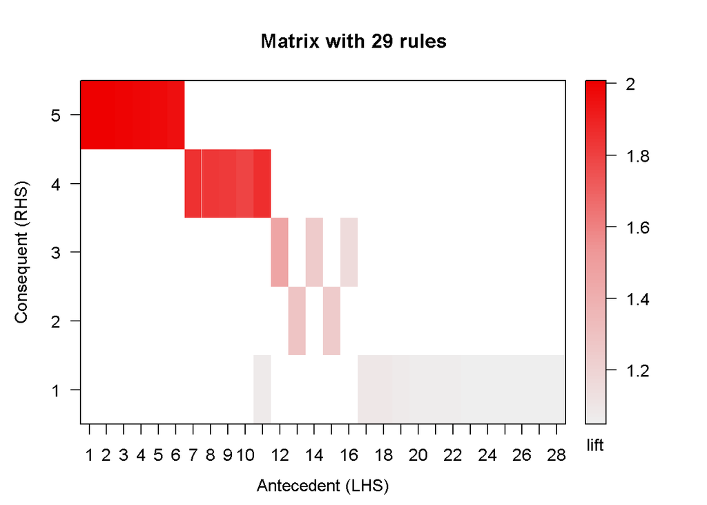

### Rules sorted by support

|  | LHS | RHS | support | confidence | lift | count |
| --- | --- | --- | --- | --- | --- | --- |
| [1] | {mortgage=mortgage=NO,pep=pep=NO} | {married=married=YES} | 0.285 | 0.818181818181818 | 1.2396694214876 | 171 |
| [2] | {married=married=NO} | {current_act=current_act=YES} | 0.27 | 0.794117647058823 | 1.04718810601164 | 162 |
| [3] | {car=car=NO,mortgage=mortgage=NO} | {current_act=current_act=YES} | 0.263333333333333 | 0.802030456852792 | 1.05762258046522 | 158 |
| [4] | {children=0,pep=pep=NO} | {married=married=YES} | 0.235 | 0.844311377245509 | 1.2792596624932 | 141 |
| [5] | {married=married=NO,save_act=save_act=YES} | {current_act=current_act=YES} | 0.188333333333333 | 0.824817518248175 | 1.08767145263496 | 113 |
| [6] | {age=twenties} | {income=(5.01e+03,2.44e+04]} | 0.186666666666667 | 0.941176470588235 | 1.9884009942005 | 112 |
| [7] | {children=1} | {pep=pep=YES} | 0.183333333333333 | 0.814814814814815 | 1.78426601784266 | 110 |
| [8] | {car=car=NO,pep=pep=YES} | {current_act=current_act=YES} | 0.183333333333333 | 0.808823529411765 | 1.06658047834518 | 110 |
| [9] | {sex=FEMALE,region=INNER_CITY} | {current_act=current_act=YES} | 0.175 | 0.801526717557252 | 1.05695830886671 | 105 |
| [10] | {married=married=NO,pep=pep=YES} | {current_act=current_act=YES} | 0.158333333333333 | 0.791666666666667 | 1.04395604395604 | 95 |

[output cut: 19 more lines]

### Rules sorted by confidence

|  | LHS | RHS | support | confidence | lift | count |
| --- | --- | --- | --- | --- | --- | --- |
| [1] | {income=(4.38e+04,6.31e+04]} | {save_act=save_act=YES} | 0.133333333333333 | 1 | 1.44927536231884 | 80 |
| [2] | {age=twenties,married=married=YES} | {income=(5.01e+03,2.44e+04]} | 0.121666666666667 | 0.948051948051948 | 2.00292665081397 | 73 |
| [3] | {age=twenties,current_act=current_act=YES} | {income=(5.01e+03,2.44e+04]} | 0.145 | 0.945652173913043 | 1.99785670545009 | 87 |
| [4] | {age=twenties} | {income=(5.01e+03,2.44e+04]} | 0.186666666666667 | 0.941176470588235 | 1.9884009942005 | 112 |
| [5] | {age=twenties,mortgage=mortgage=NO} | {income=(5.01e+03,2.44e+04]} | 0.126666666666667 | 0.938271604938272 | 1.98226395409494 | 76 |
| [6] | {age=twenties,save_act=save_act=YES} | {income=(5.01e+03,2.44e+04]} | 0.113333333333333 | 0.931506849315068 | 1.96797221686282 | 68 |
| [7] | {age=twenties,pep=pep=NO} | {income=(5.01e+03,2.44e+04]} | 0.121666666666667 | 0.924050632911392 | 1.9522196469959 | 73 |
| [8] | {age=old} | {save_act=save_act=YES} | 0.128333333333333 | 0.855555555555556 | 1.23993558776167 | 77 |
| [9] | {children=1,mortgage=mortgage=NO} | {pep=pep=YES} | 0.118333333333333 | 0.845238095238095 | 1.85088633993743 | 71 |
| [10] | {children=0,pep=pep=NO} | {married=married=YES} | 0.235 | 0.844311377245509 | 1.2792596624932 | 141 |

[output cut: 19 more lines]

### Rules sorted by lift

|  | LHS | RHS | support | confidence | lift | count |
| --- | --- | --- | --- | --- | --- | --- |
| [1] | {age=twenties,married=married=YES} | {income=(5.01e+03,2.44e+04]} | 0.121666666666667 | 0.948051948051948 | 2.00292665081397 | 73 |
| [2] | {age=twenties,current_act=current_act=YES} | {income=(5.01e+03,2.44e+04]} | 0.145 | 0.945652173913043 | 1.99785670545009 | 87 |
| [3] | {age=twenties} | {income=(5.01e+03,2.44e+04]} | 0.186666666666667 | 0.941176470588235 | 1.9884009942005 | 112 |
| [4] | {age=twenties,mortgage=mortgage=NO} | {income=(5.01e+03,2.44e+04]} | 0.126666666666667 | 0.938271604938272 | 1.98226395409494 | 76 |
| [5] | {age=twenties,save_act=save_act=YES} | {income=(5.01e+03,2.44e+04]} | 0.113333333333333 | 0.931506849315068 | 1.96797221686282 | 68 |
| [6] | {age=twenties,pep=pep=NO} | {income=(5.01e+03,2.44e+04]} | 0.121666666666667 | 0.924050632911392 | 1.9522196469959 | 73 |
| [7] | {children=1,mortgage=mortgage=NO} | {pep=pep=YES} | 0.118333333333333 | 0.845238095238095 | 1.85088633993743 | 71 |
| [8] | {children=1,save_act=save_act=YES} | {pep=pep=YES} | 0.133333333333333 | 0.842105263157895 | 1.84402612370342 | 80 |
| [9] | {children=1,current_act=current_act=YES} | {pep=pep=YES} | 0.14 | 0.831683168316832 | 1.82120401821204 | 84 |
| [10] | {married=married=YES,children=1} | {pep=pep=YES} | 0.123333333333333 | 0.831460674157303 | 1.82071680472402 | 74 |

[output cut: 19 more lines]

### Top 5 Rules

This results in only 5 rules, but they are very strong ones. Not only do they have good support, confidence and lift, but they also occur a lot. Recall there are only 600 observations in the KNJ dataset, so 110 occurances of a rule is high.

**customer segment**: Married couples with only 1 child who do business with KNJ, but not on the mortgage side.

- Children 1 rule with support of .183 is in the top 10 of all rules.
- Children 1 shows up in the antecedent of every rule in the top 5
- Current and Savings Account are YES
- No Mortgage though
- Married

**Top Five Rules**

1.) {children=1} {pep=pep=YES} 0.183 0.815 1.784 **110.000**

2.) {children=1,mortgage=mortgage=NO} {pep=pep=YES} 0.118 0.845 1.851 **71.000**

3.) {married=married=YES,children=1} {pep=pep=YES} 0.123 0.831 1.821 **74.000**

4.) {children=1,save_act=save_act=YES} {pep=pep=YES} 0.133 0.842 1.844 **80.000**

5.) {children=1,current_act=current_act=YES} {pep=pep=YES} 0.140 0.832 1.821 **84.000**

|  | LHS | RHS | support | confidence | lift | count |
| --- | --- | --- | --- | --- | --- | --- |
| [1] | {children=1} | {pep=pep=YES} | 0.183333333333333 | 0.814814814814815 | 1.78426601784266 | 110 |
| [2] | {children=1,mortgage=mortgage=NO} | {pep=pep=YES} | 0.118333333333333 | 0.845238095238095 | 1.85088633993743 | 71 |
| [3] | {married=married=YES,children=1} | {pep=pep=YES} | 0.123333333333333 | 0.831460674157303 | 1.82071680472402 | 74 |
| [4] | {children=1,save_act=save_act=YES} | {pep=pep=YES} | 0.133333333333333 | 0.842105263157895 | 1.84402612370342 | 80 |
| [5] | {children=1,current_act=current_act=YES} | {pep=pep=YES} | 0.14 | 0.831683168316832 | 1.82120401821204 | 84 |

## ArulViz Visualizations

### Plotting Top 5 Rules

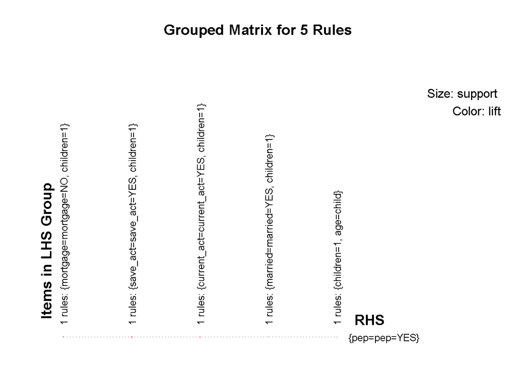

### Plot Support

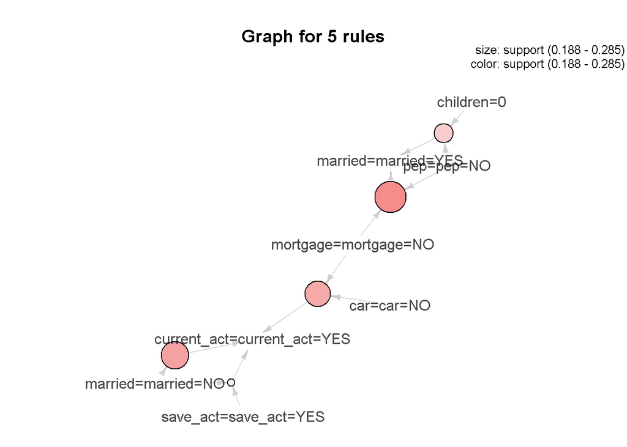

### Plot Confidence

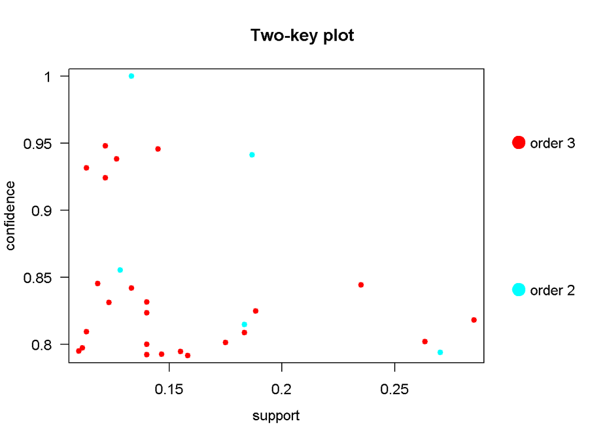

### Plot Lift

[figure not shown]

## Models

### Classification Models

#### Model Data Splitting

The data will be split into 2/3 for training set, and 1/3 for the testing set.

| dimension_training_train | dimension_testing_train |
| --- | --- |
| 400 | 200 |
| 12 | 12 |

|  | age | sex | region | income | married | children | car | save_act | current_act | mortgage | pep |
| --- | --- | --- | --- | --- | --- | --- | --- | --- | --- | --- | --- |
| 76 | 59 | FEMALE | RURAL | 35611 | NO | 2 | YES | NO | NO | NO | YES |
| 298 | 18 | MALE | RURAL | 8639 | YES | 2 | NO | NO | NO | NO | NO |
| 414 | 26 | FEMALE | INNER_CITY | 16519 | YES | 0 | YES | NO | YES | NO | YES |
| 473 | 61 | MALE | INNER_CITY | 21140 | YES | 2 | YES | YES | NO | NO | NO |
| 325 | 36 | MALE | SUBURBAN | 28495 | YES | 0 | NO | YES | YES | NO | NO |
| 499 | 51 | FEMALE | TOWN | 43800 | NO | 0 | NO | YES | YES | YES | NO |

|  | id | age | sex | region | income | married | children | car | save_act | current_act | mortgage | pep |
| --- | --- | --- | --- | --- | --- | --- | --- | --- | --- | --- | --- | --- |
| 76 | ID12176 | 59 | FEMALE | RURAL | 35611 | NO | 2 | YES | NO | NO | NO | YES |
| 298 | ID12398 | 18 | MALE | RURAL | 8639 | YES | 2 | NO | NO | NO | NO | NO |
| 414 | ID12514 | 26 | FEMALE | INNER_CITY | 16519 | YES | 0 | YES | NO | YES | NO | YES |
| 473 | ID12573 | 61 | MALE | INNER_CITY | 21140 | YES | 2 | YES | YES | NO | NO | NO |
| 325 | ID12425 | 36 | MALE | SUBURBAN | 28495 | YES | 0 | NO | YES | YES | NO | NO |
| 499 | ID12599 | 51 | FEMALE | TOWN | 43800 | NO | 0 | NO | YES | YES | YES | NO |

| dimension_testing_bd_train | dim(bd_test) |
| --- | --- |
| 400 | 200 |
| 11 | 11 |

|  | age | sex | region | income | married | children | car | save_act | current_act | mortgage | pep |
| --- | --- | --- | --- | --- | --- | --- | --- | --- | --- | --- | --- |
| 76 | fifties | FEMALE | RURAL | (2.44e+04,4.38e+04] | married=NO | 2 | car=YES | save_act=NO | current_act=NO | mortgage=NO | pep=YES |
| 298 | teens | MALE | RURAL | (5.01e+03,2.44e+04] | married=YES | 2 | car=NO | save_act=NO | current_act=NO | mortgage=NO | pep=NO |
| 414 | twenties | FEMALE | INNER_CITY | (5.01e+03,2.44e+04] | married=YES | 0 | car=YES | save_act=NO | current_act=YES | mortgage=NO | pep=YES |
| 473 | old | MALE | INNER_CITY | (5.01e+03,2.44e+04] | married=YES | 2 | car=YES | save_act=YES | current_act=NO | mortgage=NO | pep=NO |
| 325 | thirties | MALE | SUBURBAN | (2.44e+04,4.38e+04] | married=YES | 0 | car=NO | save_act=YES | current_act=YES | mortgage=NO | pep=NO |
| 499 | fifties | FEMALE | TOWN | (4.38e+04,6.31e+04] | married=NO | 0 | car=NO | save_act=YES | current_act=YES | mortgage=YES | pep=NO |

|  | age | sex | region | income | married | children | car | save_act | current_act | mortgage | pep |
| --- | --- | --- | --- | --- | --- | --- | --- | --- | --- | --- | --- |
| 76 | fifties | FEMALE | RURAL | (2.44e+04,4.38e+04] | married=NO | 2 | car=YES | save_act=NO | current_act=NO | mortgage=NO | pep=YES |
| 298 | teens | MALE | RURAL | (5.01e+03,2.44e+04] | married=YES | 2 | car=NO | save_act=NO | current_act=NO | mortgage=NO | pep=NO |
| 414 | twenties | FEMALE | INNER_CITY | (5.01e+03,2.44e+04] | married=YES | 0 | car=YES | save_act=NO | current_act=YES | mortgage=NO | pep=YES |
| 473 | old | MALE | INNER_CITY | (5.01e+03,2.44e+04] | married=YES | 2 | car=YES | save_act=YES | current_act=NO | mortgage=NO | pep=NO |
| 325 | thirties | MALE | SUBURBAN | (2.44e+04,4.38e+04] | married=YES | 0 | car=NO | save_act=YES | current_act=YES | mortgage=NO | pep=NO |
| 499 | fifties | FEMALE | TOWN | (4.38e+04,6.31e+04] | married=NO | 0 | car=NO | save_act=YES | current_act=YES | mortgage=YES | pep=NO |

### Model Data Prep

```
## [1] "Imbalance checking for pep target variable"
```

```
##
##  pep=NO pep=YES
##    0.57    0.43
```

```
## [1] "Imbalance is not a problem here as the no and yes values are nearly balanced"
```

```
## Rows: 200
## Columns: 11
## $ age         <int> 59, 18, 26, 61, 36, 51, 42, 46, 32, 55, 45, 23, 47, 37,...
## $ sex         <dbl> 0, 1, 0, 1, 1, 0, 1, 0, 1, 1, 0, 0, 1, 0, 0, 0, 1, 1, 1...
## $ region      <fct> RURAL, RURAL, INNER_CITY, INNER_CITY, SUBURBAN, TOWN, I...
## $ income      <dbl> 35611, 8639, 16519, 21140, 28495, 43800, 17390, 17149, ...
## $ married     <dbl> 0, 1, 1, 1, 1, 0, 1, 0, 0, 1, 0, 1, 0, 1, 1, 1, 1, 1, 0...
## $ children    <int> 2, 2, 0, 2, 0, 0, 0, 1, 0, 0, 0, 3, 2, 0, 1, 0, 0, 0, 0...
## $ car         <dbl> 1, 0, 1, 1, 0, 0, 0, 1, 0, 0, 0, 0, 1, 1, 1, 0, 0, 1, 0...
## $ save_act    <dbl> 0, 0, 0, 1, 1, 1, 1, 1, 1, 0, 1, 0, 1, 1, 1, 1, 1, 1, 1...
## $ current_act <dbl> 0, 0, 1, 0, 1, 1, 1, 1, 1, 1, 1, 1, 1, 1, 1, 1, 1, 1, 1...
## $ mortgage    <dbl> 0, 0, 0, 0, 0, 1, 0, 0, 0, 1, 1, 0, 0, 0, 0, 0, 0, 0, 1...
## $ pep         <fct> YES, NO, YES, NO, NO, NO, NO, YES, YES, YES, NO, NO, YE...
```

| age | sex | region | income | married | children | car | save_act | current_act | mortgage | pep |
| --- | --- | --- | --- | --- | --- | --- | --- | --- | --- | --- |
| 59 | 0 | RURAL | 35611 | 0 | 2 | 1 | 0 | 0 | 0 | YES |
| 18 | 1 | RURAL | 8639 | 1 | 2 | 0 | 0 | 0 | 0 | NO |
| 26 | 0 | INNER_CITY | 16519 | 1 | 0 | 1 | 0 | 1 | 0 | YES |
| 61 | 1 | INNER_CITY | 21140 | 1 | 2 | 1 | 1 | 0 | 0 | NO |
| 36 | 1 | SUBURBAN | 28495 | 1 | 0 | 0 | 1 | 1 | 0 | NO |
| 51 | 0 | TOWN | 43800 | 0 | 0 | 0 | 1 | 1 | 1 | NO |

```
## Rows: 200
## Columns: 12
## $ id          <fct> ID12176, ID12398, ID12514, ID12573, ID12425, ID12599, I...
## $ age         <int> 59, 18, 26, 61, 36, 51, 42, 46, 32, 55, 45, 23, 47, 37,...
## $ sex         <dbl> 0, 1, 0, 1, 1, 0, 1, 0, 1, 1, 0, 0, 1, 0, 0, 0, 1, 1, 1...
## $ region      <fct> RURAL, RURAL, INNER_CITY, INNER_CITY, SUBURBAN, TOWN, I...
## $ income      <dbl> 35611, 8639, 16519, 21140, 28495, 43800, 17390, 17149, ...
## $ married     <dbl> 0, 1, 1, 1, 1, 0, 1, 0, 0, 1, 0, 1, 0, 1, 1, 1, 1, 1, 0...
## $ children    <int> 2, 2, 0, 2, 0, 0, 0, 1, 0, 0, 0, 3, 2, 0, 1, 0, 0, 0, 0...
## $ car         <dbl> 1, 0, 1, 1, 0, 0, 0, 1, 0, 0, 0, 0, 1, 1, 1, 0, 0, 1, 0...
## $ save_act    <dbl> 0, 0, 0, 1, 1, 1, 1, 1, 1, 0, 1, 0, 1, 1, 1, 1, 1, 1, 1...
## $ current_act <dbl> 0, 0, 1, 0, 1, 1, 1, 1, 1, 1, 1, 1, 1, 1, 1, 1, 1, 1, 1...
## $ mortgage    <dbl> 0, 0, 0, 0, 0, 1, 0, 0, 0, 1, 1, 0, 0, 0, 0, 0, 0, 0, 1...
## $ pep         <fct> YES, NO, YES, NO, NO, NO, NO, YES, YES, YES, NO, NO, YE...
```

| id | age | sex | region | income | married | children | car | save_act | current_act | mortgage | pep |
| --- | --- | --- | --- | --- | --- | --- | --- | --- | --- | --- | --- |
| ID12176 | 59 | 0 | RURAL | 35611 | 0 | 2 | 1 | 0 | 0 | 0 | YES |
| ID12398 | 18 | 1 | RURAL | 8639 | 1 | 2 | 0 | 0 | 0 | 0 | NO |
| ID12514 | 26 | 0 | INNER_CITY | 16519 | 1 | 0 | 1 | 0 | 1 | 0 | YES |
| ID12573 | 61 | 1 | INNER_CITY | 21140 | 1 | 2 | 1 | 1 | 0 | 0 | NO |
| ID12425 | 36 | 1 | SUBURBAN | 28495 | 1 | 0 | 0 | 1 | 1 | 0 | NO |
| ID12599 | 51 | 0 | TOWN | 43800 | 0 | 0 | 0 | 1 | 1 | 1 | NO |

#### Model Training

Apriori classifier was shown to be 100% accurate in predicting pep responders. This means we can use a classifier based upon aprior to determine the target audience if we assume pep response is a good index for propensity to respond.

CBA classifer accuracy is 1 or 100% accuracy"

```
## CBA Classifier Object
## Class:
## Default Class: NA
## Number of rules: 21
## Classification method: first
## Description: CBA algorithm (Liu et al., 1998)
```

```
## [1] "CBA classifer accuracy is  1  or 100% accuracy"
```

##### Training Other Classifer Models: Random Forest and Support Vector Machines

The results of the association rule based predictions were quite high, so other classifiaction method will be used to challenge or confirm.

#### Model Testing

Testing for random forest and support vector machine classifers. The most important features for the Random forest algorithm can be seen below here. **Income** is the most important by far followed by children.

```
## rf variable importance
##
##                Overall
## income         100.000
## children        72.324
## age             36.619
## mortgage        26.776
## save_act        21.867
## married         20.302
## sex              4.896
## regionRURAL      1.949
## car              1.327
## current_act      0.691
## regionSUBURBAN   0.275
## regionTOWN       0.000
```

# Results

## Model Training Results

Definition of the Terms related to measuring classification models:

- Positive (P) : Observation is positive (for example: is an apple).
- Negative (N) : Observation is not positive (for example: is not an apple).
- True Positive (TP) : Observation is positive, and is predicted to be positive.
- False Negative (FN) : Observation is positive, but is predicted negative.
- True Negative (TN) : Observation is negative, and is predicted to be negative.
- False Positive (FP) : Observation is negative, but is predicted positive.

**Accuracy**: * Classification Rate or Accuracy is given by the relation: (TP + TN) / (TP + TN + FP + FN) * It assumes equal costs for both kinds of errors. A 99% accuracy can be excellent, good, mediocre, poor or terrible depending upon the problem.

**Recall**: Recall can be defined as the ratio of the total number of correctly classified positive examples divide to the total number of positive examples. High Recall indicates the class is correctly recognized (a small number of FN). Recall is given by the relation: TP / (TP + FN)

```
##
## Call:
## summary.resamples(object = results)
##
## Models: svm, rf
## Number of resamples: 10
##
## Accuracy
##     Min. 1st Qu. Median Mean 3rd Qu. Max. NA's
## svm 0.45    0.66   0.75 0.72    0.80 0.85    0
## rf  0.70    0.80   0.88 0.87    0.95 1.00    0
##
## Kappa
##      Min. 1st Qu. Median Mean 3rd Qu. Max. NA's
## svm -0.10    0.27   0.48 0.41    0.59 0.69    0
## rf   0.32    0.60   0.75 0.72    0.90 1.00    0
```

### Support Vector Machine and Random Forest plotting results

The graph below shows two evaluation metrics for the models.

- Accuracy is the percentage of correctly classifies instances out of all instances. It is more useful on a binary classification than multi-class classification problems because it can be less clear exactly how the accuracy breaks down across those classes (e.g. you need to go deeper with a confusion matrix). Learn more about Accuracy here.
- Kappa or Cohen’s Kappa is like classification accuracy, except that it is normalized at the baseline of random chance on your dataset. It is a more useful measure to use on problems that have an imbalance in the classes (e.g. 70-30 split for classes 0 and 1 and you can achieve 70% accuracy by predicting all instances are for class 0). Learn more about Kappa here.

The random forest algorithm denoted by *rf* is the better model according to these metrics.

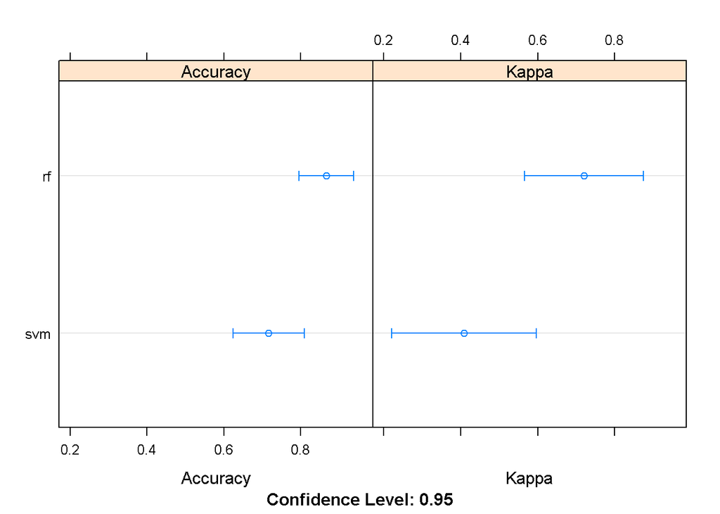

The last graph is plotting AUC-ROC and the random forest(rf) shows more area under the curve as compared to the support vector machine (svm) denoted by the red line. This means the random forest is a better fit for the data by this AUc-ROC metric.

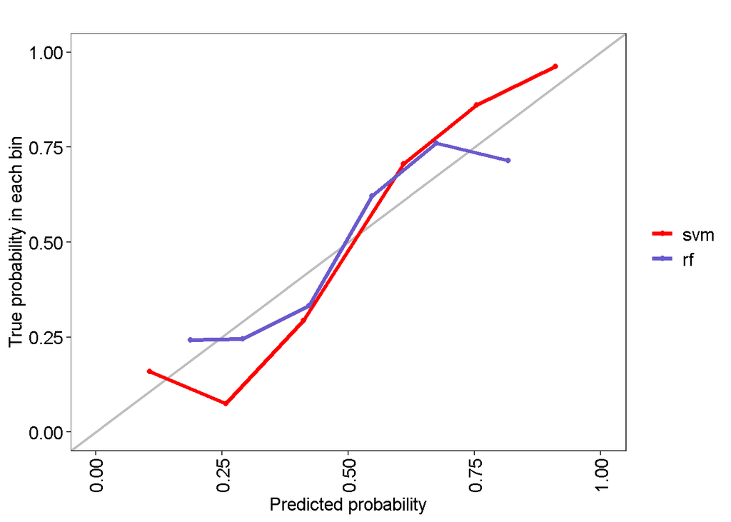

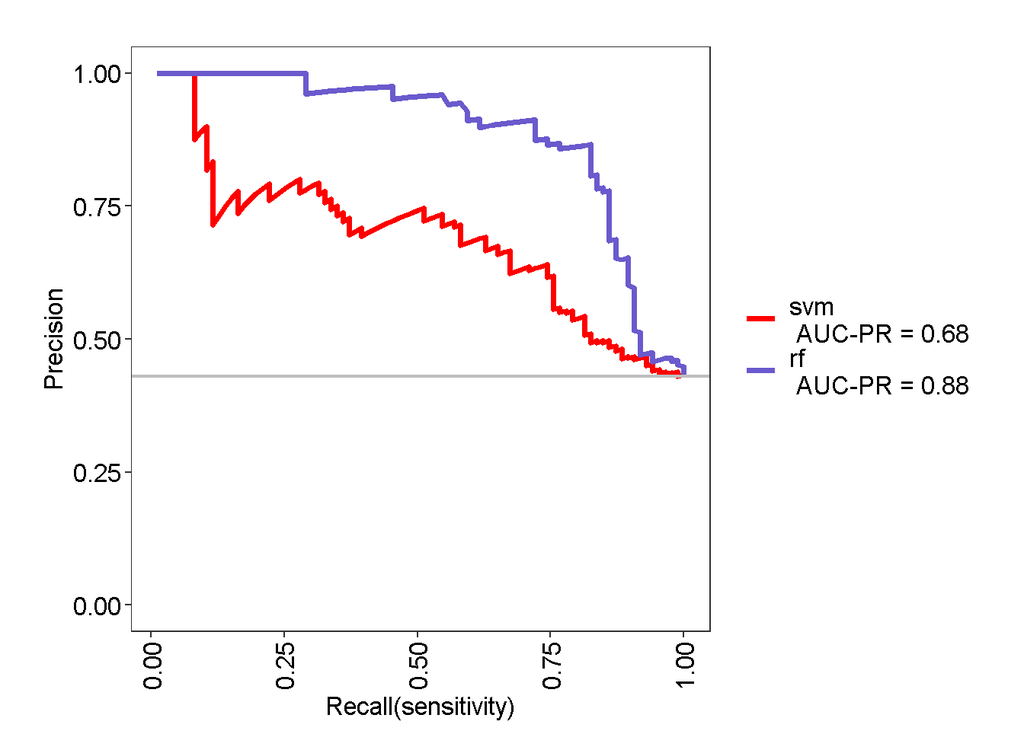

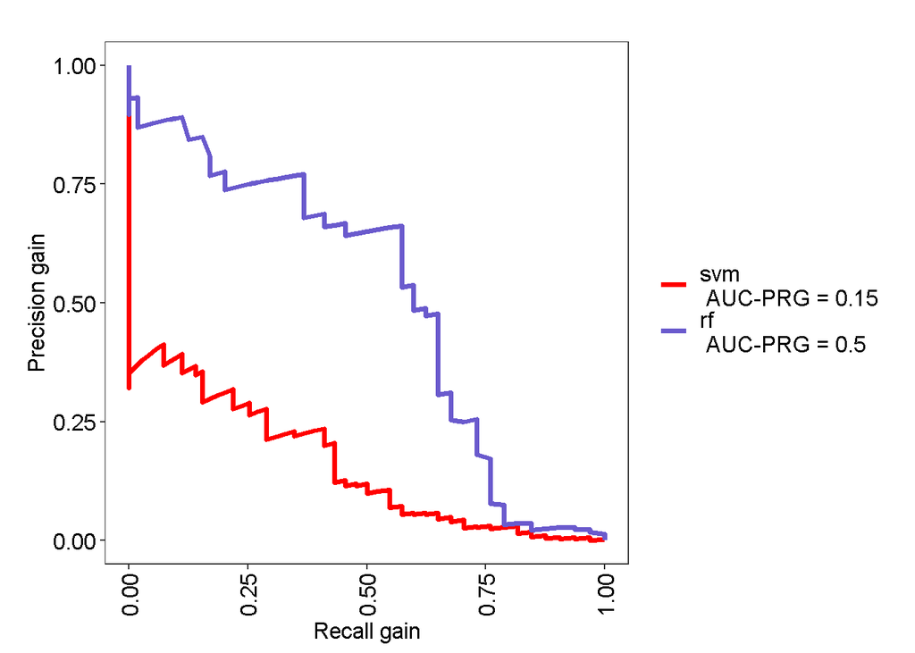

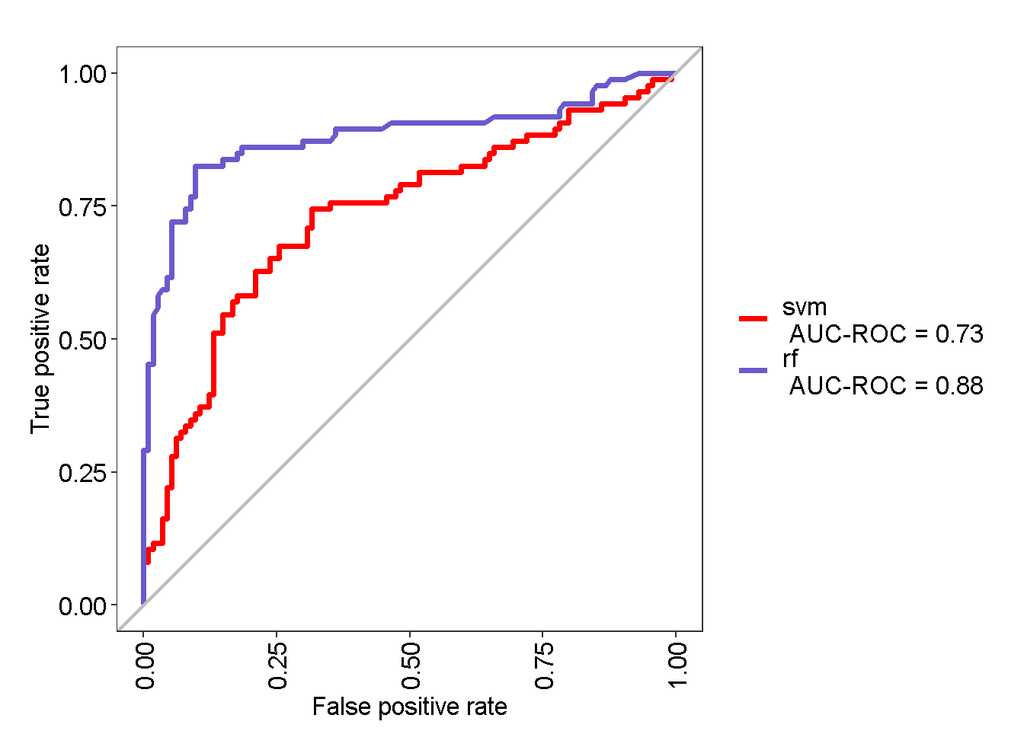

## Model Testing Results

### Confusion Matrix

The random forest classifer was also able to get 100% accuracy predicting pep response using the test dataset.

```
## Confusion Matrix and Statistics
##
##           Reference
## Prediction  NO YES
##        NO  114   0
##        YES   0  86
##
##                Accuracy : 1
##                  95% CI : (0.982, 1)
##     No Information Rate : 0.57
##     P-Value [Acc > NIR] : <2e-16
##
##                   Kappa : 1
##
##  Mcnemar's Test P-Value : NA
##
##             Sensitivity : 1.00
##             Specificity : 1.00
##          Pos Pred Value : 1.00
##          Neg Pred Value : 1.00
##              Prevalence : 0.57
##          Detection Rate : 0.57
##    Detection Prevalence : 0.57
##       Balanced Accuracy : 1.00
##
##        'Positive' Class : NO
##
```

The support vector machine had significant as well with 85% accuracy.

```
## Confusion Matrix and Statistics
##
##           Reference
## Prediction  NO YES
##        NO  107  22
##        YES   7  64
##
##                Accuracy : 0.855
##                  95% CI : (0.798, 0.901)
##     No Information Rate : 0.57
##     P-Value [Acc > NIR] : < 2e-16
##
##                   Kappa : 0.698
##
##  Mcnemar's Test P-Value : 0.00933
##
##             Sensitivity : 0.939
##             Specificity : 0.744
##          Pos Pred Value : 0.829
##          Neg Pred Value : 0.901
##              Prevalence : 0.570
##          Detection Rate : 0.535
##    Detection Prevalence : 0.645
##       Balanced Accuracy : 0.841
##
##        'Positive' Class : NO
##
```

# Conclusions

Association rule mining algorithms typically generate a large number of association rules, which poses a major problem for understanding and analyzing rules. The analysis performed here demonstrated the ability to to mine rules from the KNJ financial data using the apriori technique. Our process found 29 strong rules, but we filtered those rules down even further to our 5 strongest rules. The metrics measured to gauge rule strength were support, confidence and lift and there was an important filter used to consider past responders as the mostly likely to respond again.

The premise of past responders being the index for future responders was bolstered by using classification models. The classification models were trained to perdict passed responders by using the pep response feature. The classification approach simply tried to determine yes or no in terms of customer response After using several classification methods it is safe to say our premise of using past responses as a means to segment the customer, was an informed one. Two out of three models tested predicted with 100% accuracy, which isn’t surprising given the strength of the rules we found using the apriori rule mining methods.